# Rural and Evangelical

2016-12-02

```r
library(ggplot2)
library(foreign)
library(gridExtra)
library(RColorBrewer)
library(choroplethr)
library(choroplethrMaps)
library(viridis)
library(dplyr)
library(DT)
library(knitr)
```

I got the county level voting datafile from [here](https://github.com/mkearney/presidential_election_county_results_2016)

I got the 2010 religious census data from [here](http://www.thearda.com/Archive/Files/Descriptions/RCMSCY10.asp)

```r
vote <- read.csv("D:/2016_election/pres16results.csv", stringsAsFactors = FALSE)
vote$fips <- gsub("(?<![0-9])0+", "", vote$fips, perl = TRUE)
census <- read.dta("D:/2016_election/relcensus.dta", convert.factors = FALSE)
merge <- merge(census, vote, by=c("fips"))
suburbs <- read.csv("D:/2016_election/suburb.csv")
merge <- merge(merge, suburbs, by=c("fips"))
pres <- filter(merge, cand_name == "Donald Trump" | cand_name == "Hillary Clinton")
trump <- filter(merge, cand_name == "Donald Trump")
clinton <- filter(merge, cand_name == "Hillary Clinton")
trump$diff <- trump$pct - clinton$pct
```

## Rural Counties

There is no set definition of what rural means, so here’s what I did:

```r
df <- select(trump, cntyname, stabbr, fips, votes, total, pct, POP2010, evanrate, code)
summary(df$POP2010)
```

```
##    Min. 1st Qu.  Median    Mean 3rd Qu.    Max.
##      82   11310   26080   99010   67080 9819000
```

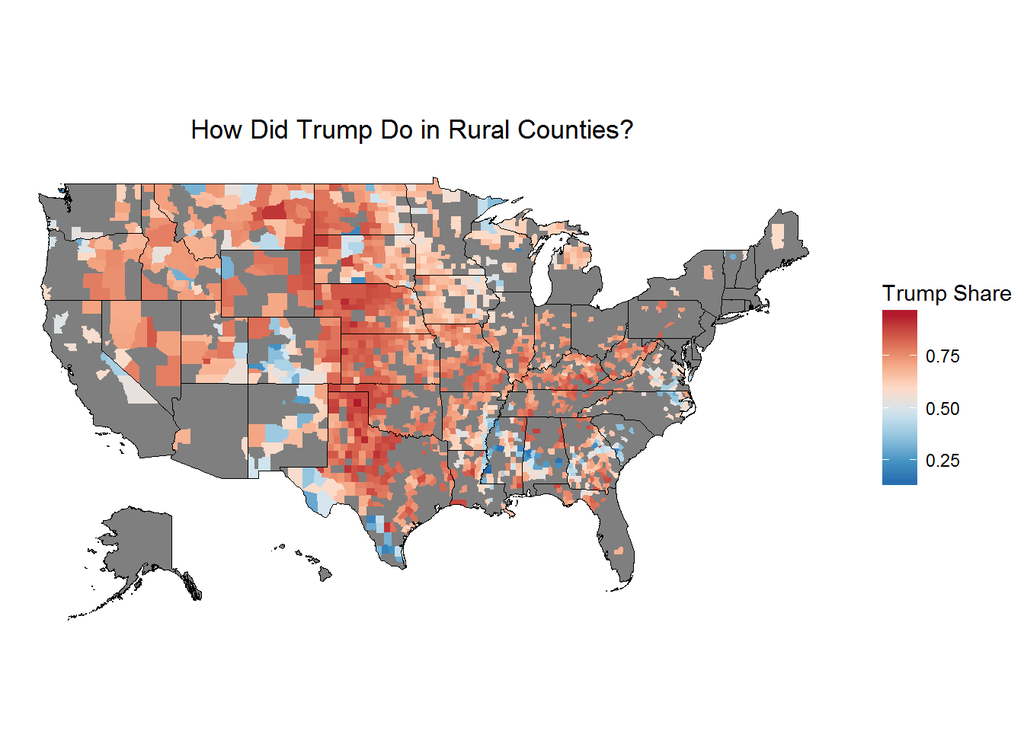

```r
rural <- filter(df, POP2010 <=26080)
rural$region <- rural$fips
rural$value <- rural$pct
palette_rev <- rev(brewer.pal(8, "RdBu"))
choro = CountyChoropleth$new(rural)
choro$title = "                         How Did Trump Do in Rural Counties?                                "
choro$set_num_colors(1)
choro$ggplot_polygon = geom_polygon(aes(fill = value), color = NA)
choro$ggplot_scale = scale_fill_gradientn(name = "Trump Share", colours = palette_rev)
choro$render()
```

## Counties with Above Average Evangelicals

Let’s do the same with evangelicals.

```r
summary(df$evanrate)
```

```
##    Min. 1st Qu.  Median    Mean 3rd Qu.    Max.    NA's
##     0.0   107.7   190.5   233.8   334.1  1309.0      18
```

The median here is 190.5 evangelicals per 1000. So any county that’s 19.1% evangelical is in this subset.

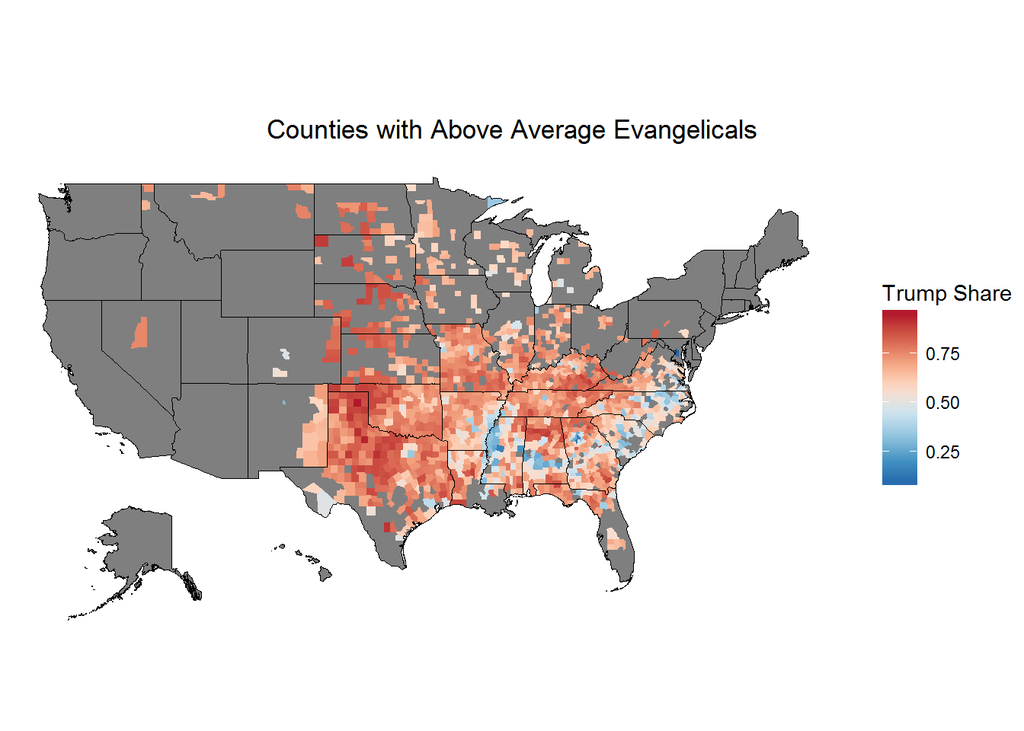

```r
high_evan <- filter(df, evanrate >= 190.5)
high_evan$region <- high_evan$fips
high_evan$value <- high_evan$pct
palette_rev <- rev(brewer.pal(8, "RdBu"))
choro = CountyChoropleth$new(high_evan)
choro$title = "                                   Counties with Above Average Evangelicals"
choro$set_num_colors(1)
choro$ggplot_polygon = geom_polygon(aes(fill = value), color = NA)
choro$ggplot_scale = scale_fill_gradientn(name = "Trump Share", colours = palette_rev)
choro$render()
```

## Let’s Combine Rural and High Evangelical

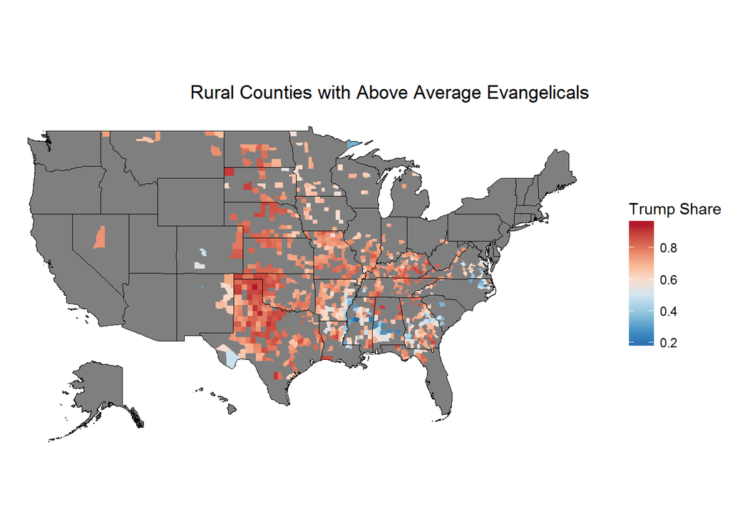

```r
rural_evan <- filter(df, POP2010 <=26080 & evanrate >= 190.5)
rural_evan$region <- rural_evan$fips
rural_evan$value <- rural_evan$pct
palette_rev <- rev(brewer.pal(8, "RdBu"))
choro = CountyChoropleth$new(rural_evan)
choro$title = "                                   Rural Counties with Above Average Evangelicals"
choro$set_num_colors(1)
choro$ggplot_polygon = geom_polygon(aes(fill = value), color = NA)
choro$ggplot_scale = scale_fill_gradientn(name = "Trump Share", colours = palette_rev)
choro$render()
```

## A Searchable Table

```r
table <- select(rural_evan, cntyname, stabbr, pct, POP2010, evanrate)
table$pct <- round(table$pct, 2)
table$evanrate <- round(table$evanrate, 2)
datatable(table, colnames =  c("County", "State", "Trump's Percentage", "2010 Population", "Total Evangelicals per 1000"))
```

|  | County | State | Trump's Percentage | 2010 Population | Total Evangelicals per 1000 |
| --- | --- | --- | --- | --- | --- |
| 1 | Bibb County | AL | 0.77 | 22915 | 443.33 |
| 2 | Bullock County | AL | 0.24 | 10914 | 197.18 |
| 3 | Butler County | AL | 0.56 | 20947 | 413.09 |
| 4 | Cherokee County | AL | 0.84 | 25989 | 418.06 |
| 5 | Choctaw County | AL | 0.56 | 13859 | 438.7 |
| 6 | Clarke County | AL | 0.55 | 25833 | 527.77 |
| 7 | Clay County | AL | 0.8 | 13932 | 638.75 |
| 8 | Cleburne County | AL | 0.88 | 14972 | 696.97 |
| 9 | Conecuh County | AL | 0.52 | 13228 | 324.84 |
| 10 | Coosa County | AL | 0.65 | 11539 | 362.25 |

[output cut: 842 more lines]

## So, how many rural, highly evangelical counties voted for Hillary Clinton?

```r
dim(rural_evan)
```

```
## [1] 852  11
```

```r
hrc <- filter(rural_evan, pct <=.5)
dim(hrc)
```

```
## [1] 63 11
```

There were 852 counties in the total dataset and just 63 had a majority of the votes for Clinton. Trump carried 92.6% of those counties.

## Suburban, Urban, Rural Data

The [CDC provides a classification scheme](http://www.cdc.gov/nchs/data_access/urban_rural.htm) for urban, suburban, rural. It’s actually six categories:

- 1. Large central metro
- 2. Large fringe metro
- 3. Medium metro
- 4. Small metro
- 5. Micropolitan
- 6. Non-core

Here’s how it breaks down in a map.

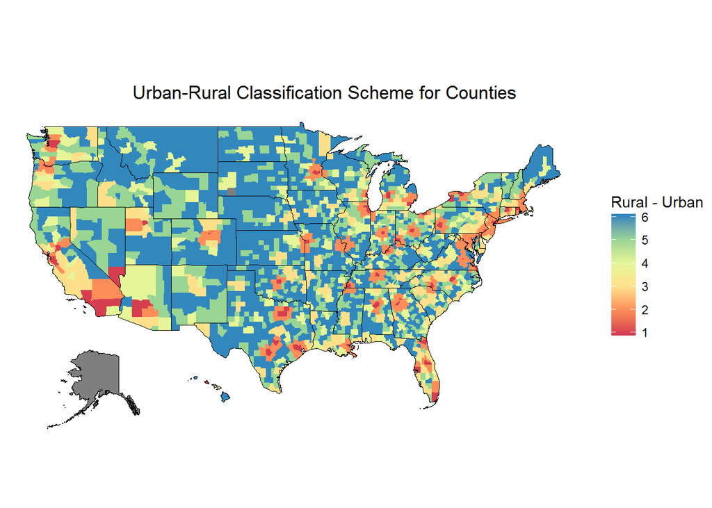

```r
df$region <- df$fips
df$value <- df$code
palette_rev <- rev(brewer.pal(8, "RdBu"))
choro = CountyChoropleth$new(df)
choro$title = "                         Urban-Rural Classification Scheme for Counties                                "
choro$set_num_colors(1)
choro$ggplot_polygon = geom_polygon(aes(fill = value), color = NA)
choro$ggplot_scale = scale_fill_gradientn(name = "Rural - Urban", colours = brewer.pal(6, "Spectral"))
choro$render()
```

## How are evangelicals distributed through these six regions?

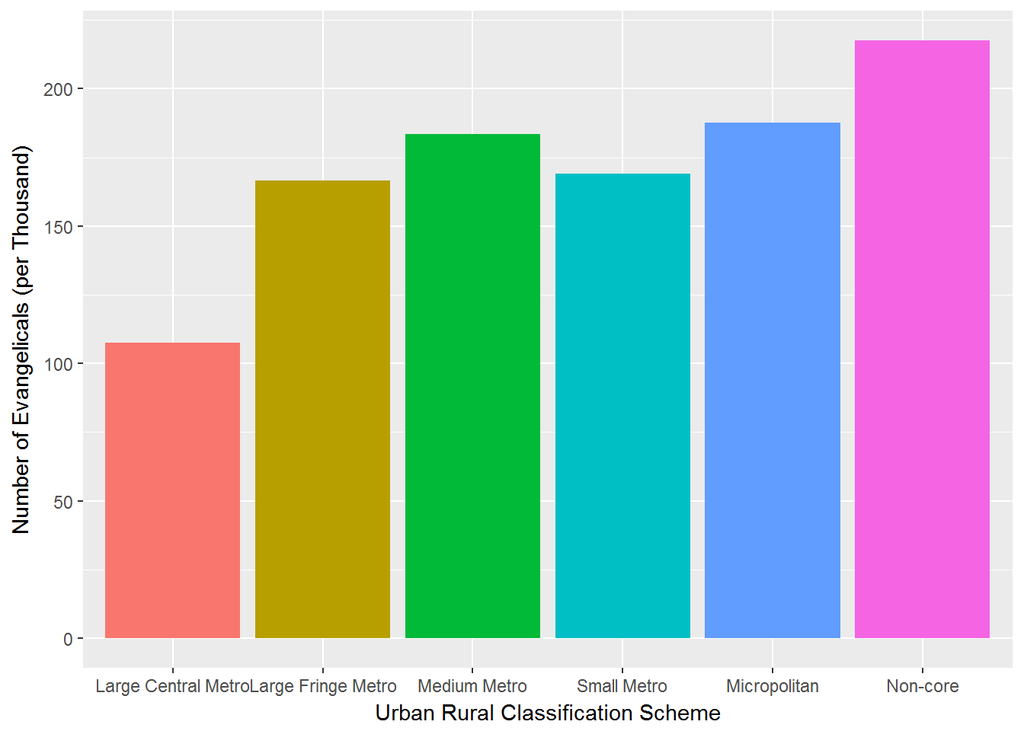

```r
a1 <- df %>% group_by(code) %>% summarise(avg_evan = median(evanrate, na.rm = TRUE), trump_vote = median(pct, na.rm = TRUE), total_pop = sum(POP2010, na.rm = TRUE))

a1$code[a1$code==1]<-"Large Central Metro"
a1$code[a1$code==2]<-"Large Fringe Metro"
a1$code[a1$code==3]<-"Medium Metro"
a1$code[a1$code==4]<-"Small Metro"
a1$code[a1$code==5]<-"Micropolitan"
a1$code[a1$code==6]<-"Non-core"
a1$code <- factor(a1$code, levels=unique(a1$code))
ggplot(a1, aes(x=code, y=avg_evan, fill= code)) + geom_col() + xlab("Urban Rural Classification Scheme") + ylab("Number of Evangelicals (per Thousand)") + theme(legend.position="none")
```

There are definitely more evangelicals in rural areas than in more densely populated areas (by percentage). Large central metros are 10.7% evangelical, and non-core areas are 21.7% evangelical.

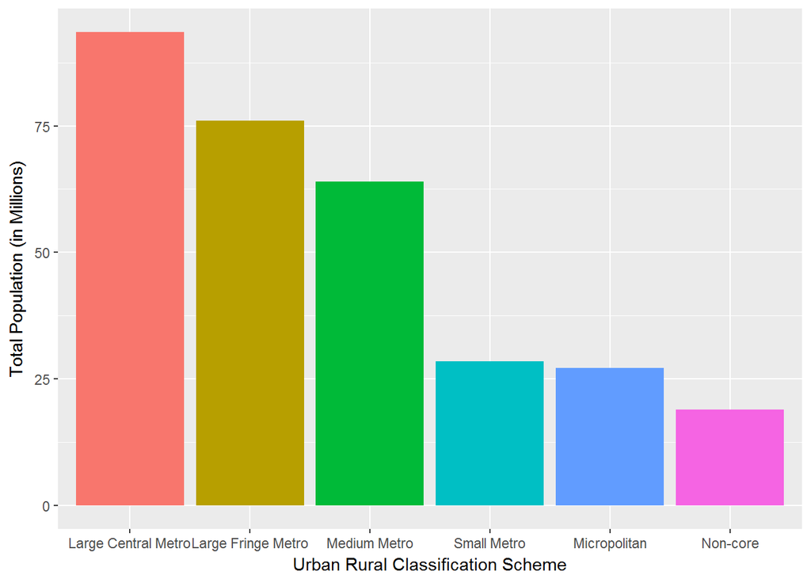

```r
ggplot(a1, aes(x=code, y=total_pop/1000000, fill= code)) + geom_col() + xlab("Urban Rural Classification Scheme") + ylab("Total Population (in Millions)") + theme(legend.position="none")
```

The issue here is that there A LOT more people that live in the metro areas than in the other areas.

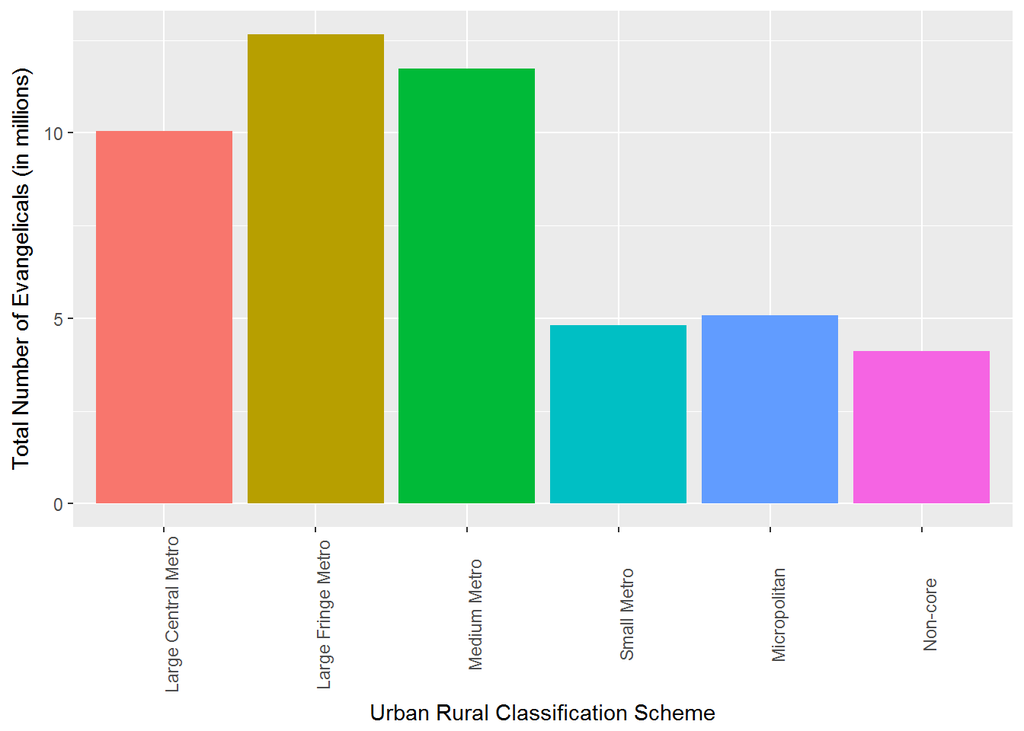

```r
a1$evan_percent <- a1$avg_evan/1000
a1$total_evan <- a1$total_pop * a1$evan_percent
a1$percent_total <- a1$total_evan/sum(a1$total_evan)
ggplot(a1, aes(x=code, y=total_evan/1000000, fill= code)) + geom_col() + theme(axis.text.x = element_text(angle = 90)) + theme(legend.position="none") + xlab("Urban Rural Classification Scheme") + ylab("Total Number of Evangelicals (in millions)")
```

Here’s the upshot of the whole thing. While rural areas are twice as evangelical as the largest metropolitan area, just 8.5% of all evangelicals in the United States live in the “non-core” counties. Even if you add “micropolitan” to “non-core” there are still more evangelicals living in big cities.

## Another Table

```r
table2 <- select(a1, code, trump_vote, total_pop, evan_percent, total_evan, percent_total)
table2$percent_total <- round(table2$percent_total, 2)
table2 <- data.frame(table2)
table2 <- table2 %>% rename("Classification" = code, "Trump Vote" = trump_vote, "Total Population" = total_pop, "Percent Evangelical" = evan_percent, "Total Evangelicals" = total_evan, "Percentage of All Evangelicals in Each Classification" = percent_total)
kable(table2)
```

| Classification | Trump Vote | Total Population | Percent Evangelical | Total Evangelicals | Percentage of All Evangelicals in Each Classification |
| --- | --- | --- | --- | --- | --- |
| Large Central Metro | 0.3375237 | 93505527 | 0.1073894 | 10041507 | 0.21 |
| Large Fringe Metro | 0.6030650 | 76007372 | 0.1665800 | 12661308 | 0.26 |
| Medium Metro | 0.5946537 | 63982250 | 0.1833244 | 11729510 | 0.24 |
| Small Metro | 0.6296317 | 28472269 | 0.1689100 | 4809251 | 0.10 |
| Micropolitan | 0.6606895 | 27109461 | 0.1875444 | 5084229 | 0.10 |
| Non-core | 0.7216858 | 18938530 | 0.2174544 | 4118268 | 0.09 |

## How Did Trump’s Margins Compare to Romney’s in 2012?

```r
a1<- merge %>% filter(evanrate >250) %>% summarise(mean_trump = mean(trumppct), mean_romney = mean(romneypct))
a2<- merge %>% filter(evanrate >500) %>% summarise(mean_trump = mean(trumppct), mean_romney = mean(romneypct))
a3<- merge %>% filter(evanrate >250 & POP2010 <25000) %>% summarise(mean_trump = mean(trumppct), mean_romney = mean(romneypct))
a4<- merge %>% filter(evanrate >500 & POP2010 <25000) %>% summarise(mean_trump = mean(trumppct), mean_romney = mean(romneypct))
a5 <- rbind(a1, a2, a3, a4)
a5$trump_advantage <- a5$mean_trump - a5$mean_romney
a5$description <- c("25%+ Evangelical", "50%+ Evangelical", "25%+ Evangelical and Population < 25000", "50%+ Evangelical and Population < 25000")
table3 <- a5 %>% rename("Trump Vote Share" = mean_trump, "Romney Vote Share" = mean_romney, "Trump's Margin over Romney" = trump_advantage, "Description" = description)
kable(table3)
```

| Trump Vote Share | Romney Vote Share | Trump’s Margin over Romney | Description |
| --- | --- | --- | --- |
| 70.45250 | 66.40706 | 4.045439 | 25%+ Evangelical |
| 75.76940 | 71.30000 | 4.469397 | 50%+ Evangelical |
| 72.86672 | 67.89076 | 4.975959 | 25%+ Evangelical and Population < 25000 |
| 76.76108 | 71.93681 | 4.824279 | 50%+ Evangelical and Population < 25000 |